# 4.4 Report Exercise

Manuel Summermatter

2023-03-20

# Telling a story from data

## Introduction

This Exercise has the goal to tell a story from the airquality data set, which is directly available in R. Through different visualizations and statistical analyses, the data should be understood.

## Methods and Results

First, I set up the work space and load the data. I then also clean it so that the time information is in a concise way. The data contains air quality measurements in New York, obtained from May to September 1973.

```r
library(tidyverse)
library(lubridate)
airquality <- datasets::airquality

airquality <- airquality |>
  mutate(date = as_date(paste("1973", Month, Day, sep = "-")), Month = NULL, Day = NULL)
```

The data now consists of 5 variables with 153 observations. The variables are Ozone (measured in part per billion), Solar radiation (measured in Langleys), Wind speed (in miles per hour), Temperature (maximum daily temperature measured in degrees Fahrenheit) and date (measuring year, month and day of the observation).

What follows is a visual presentation of the temporal pattern of the wind speed.

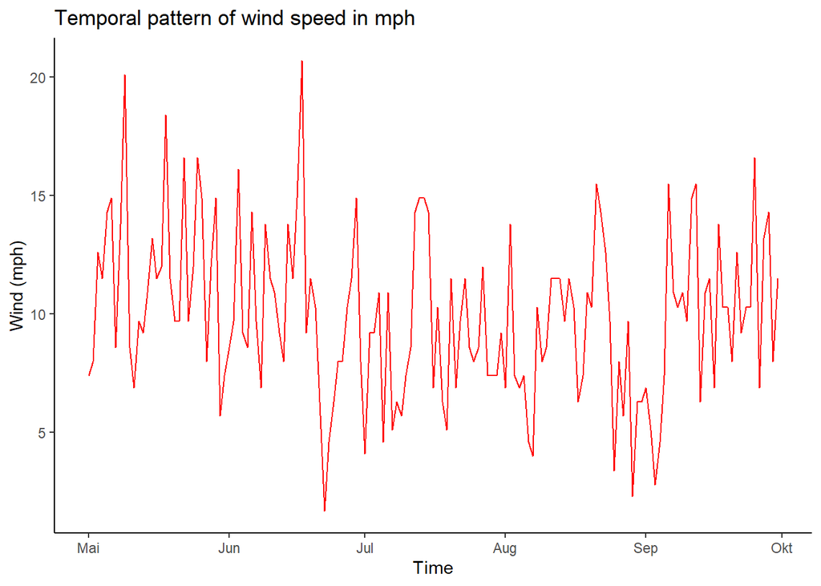

```r
airquality |>
  ggplot(
    aes(x = date, y = Wind)
  ) +
  geom_line(colour = "red") +
  labs(title = "Temporal pattern of wind speed in mph", x = "Time", y = "Wind (mph)") +
  theme_classic()
```

This visualization firstly shows that there are a lot of fluctuations in the temporal pattern of wind speed. Secondly, it shows that the average of the wind speed (subtracting these fluctuations) declines mid-June and stays lower until mid-September, when it starts to increase again.

I will now present a scatter plot of wind speed and temperature, outlining any significant correlation between these two variables.

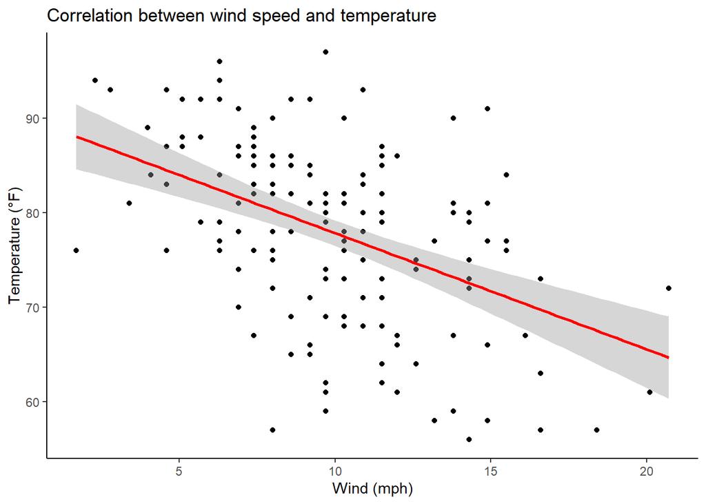

```r
airquality |>
  ggplot(
    aes(x = Wind, y = Temp)
  ) +
  geom_point() +
  geom_smooth(method = "lm", colour = "red") +
  labs(title = "Correlation between wind speed and temperature", x = "Wind (mph)", y = "Temperature (°F)") +
  theme_classic()
```

The red line represents the linear regression line. Its negative slope shows that there is a negative correlation between wind speed and temperature. This means that, in tendency, if wind speed is large, temperature is low and vice versa.

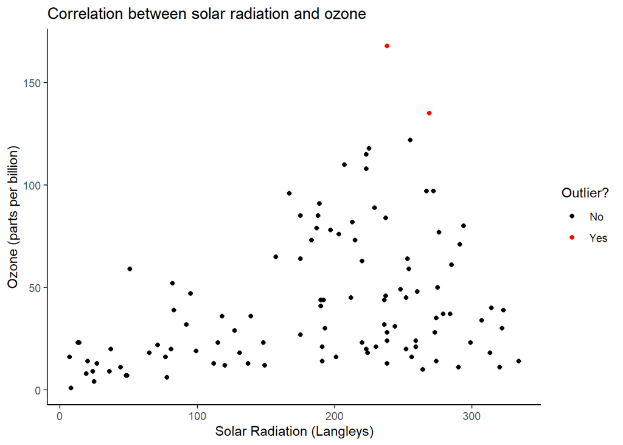

```r
outliers <- boxplot.stats(airquality$Ozone)$out

airquality_plot <- airquality |>
  mutate(outlier = Ozone %in% outliers)

airquality_plot |>
  ggplot(
    aes(x = Solar.R, y = Ozone, colour = outlier)
  ) +
  geom_point() +
  scale_colour_manual("Outlier?", values = c("black", "red"), labels = c("No", "Yes")) +
  labs(title = "Correlation between solar radiation and ozone", x = "Solar Radiation (Langleys)", y = "Ozone (parts per billion)") +
  theme_classic()
```

What follows is a statistical description of the data set with different metrics.  
First, I remove any previously generated data values and reset the data set to its initial structure

```r
rm(list=ls())
airquality <- datasets::airquality
```

I start this statistical description part by calculating a description of the mean temperature per month. This is important as it shows the trend in temperatures over the course of a longer time period (In the data set, there are unfortunately only 5 months)

```r
knitr::kable(airquality |>
  group_by(Month) |>
  summarise(MeanTemp = mean(Temp))
, caption = "Mean Temperature per Month")
```

Mean Temperature per Month

| Month | MeanTemp |
| --- | --- |
| 5 | 65.54839 |
| 6 | 79.10000 |
| 7 | 83.90323 |
| 8 | 83.96774 |
| 9 | 76.90000 |

It can be seen that the mean temperature is the highest in July and August, which is not surprising when thinking of New York’s climograph. From the months available, May has the lowest mean temperatures.

Second, I analyse the correlation between wind speed and temperature. This is interesting as one’s intuition out of personal experience probably speaks in favor of such a correlation. I do this by calculating the correlation coefficient.

```r
cor(airquality$Wind, airquality$Temp)
```

```
## [1] -0.4579879
```

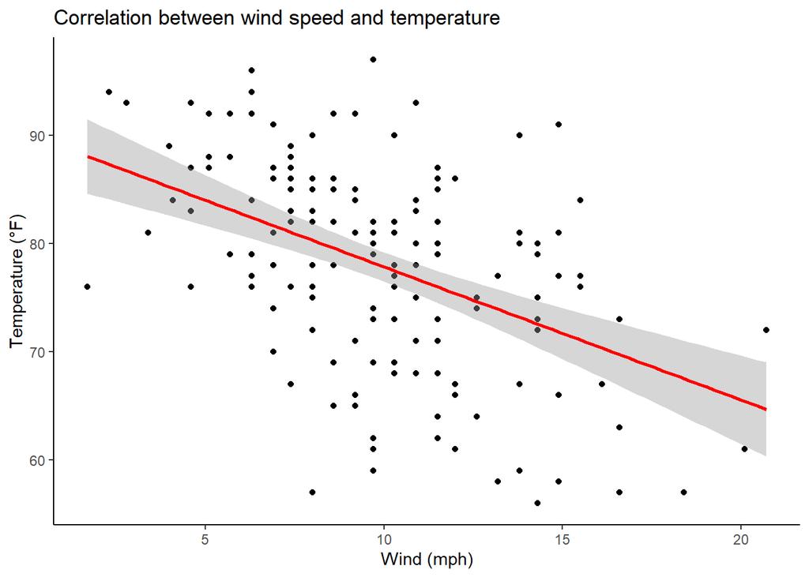

```r
airquality |>
  ggplot(
    aes(x = Wind, y = Temp)
      ) +
      geom_point() +
      geom_smooth(method = "lm", colour = "red") +
  labs(title = "Correlation between wind speed and temperature", x = "Wind (mph)", y = "Temperature (°F)") +
  theme_classic()
```

The correlation coefficient is -0.4579879, so there is a negative correlation between wind speed and temperature over the course of the time period of the data set (May to September). This fact can also be seen in the scatter plot through the negative slope of the regression line.

Third, I will analyze if, and to what extend, the variance of Ozone can be explained by Solar radiation. I therefore build a linear regression model in the form of Ozone ~ Solar radiation.

```r
model <- lm(Ozone ~ Solar.R, data = airquality)
summary(model)
```

```
##
## Call:
## lm(formula = Ozone ~ Solar.R, data = airquality)
##
## Residuals:
##     Min      1Q  Median      3Q     Max
## -48.292 -21.361  -8.864  16.373 119.136
##
## Coefficients:
##             Estimate Std. Error t value Pr(>|t|)
## (Intercept) 18.59873    6.74790   2.756 0.006856 **
## Solar.R      0.12717    0.03278   3.880 0.000179 ***
## ---
## Signif. codes:  0 '***' 0.001 '**' 0.01 '*' 0.05 '.' 0.1 ' ' 1
##
## Residual standard error: 31.33 on 109 degrees of freedom
##   (42 Beobachtungen als fehlend gelöscht)
## Multiple R-squared:  0.1213, Adjusted R-squared:  0.1133
## F-statistic: 15.05 on 1 and 109 DF,  p-value: 0.0001793
```

The coefficient of Solar radiation is 0.12717. This means that if Solar radiation increases by 1 Langley, Ozone increases by 0.12717 parts per billion. This effect is statistically significant on the 1% level, as the respective p value is 0.000179 which is smaller than 0.01